# Assignment 3: Image Colourization [50 Pt]

# PART C (Optional) - Bonus Challenge!

This is an optional exercise for those that finish the assignment early and would like to perform a deeper exploration of the concepts introduced in the assignment.

In Part A we constructed an autoencoder, specifically a UNet architecture with skip connections to learn to colourize images. In Part B completed the same task using conditional GANs. For this bonus challenge we will explore several other techniques that could be used to improve the model's performance on image colourization. A great tutorial on some of these different approaches can be found in a [blog post by Moein Shariatnia](https://towardsdatascience.com/colorizing-black-white-images-with-u-net-and-conditional-gan-a-tutorial-81b2df111cd8). It is highly recommended that you read the article before completing the following tasks:

Tasks:

1. Modify your conditional GAN architecture to incorporate a pretrained ResNet model to speed up and improve the generative abilities for image colourization.
2. Modify your conditional GAN architecture to incorporate the patch discriminator trained on local regions in the images.
3. Modify your conditional GAN architecture to use higher resolution images of upto 256 x 256 resolution and compare the performance. Summarize how performance changes with increasing resolution of images. Hint: for this task you will need to use another dataset, perhaps COCO, or ImageNet.
4. Modify your conditional GAN architecture to incorporate lab colour space image data representation instead of RGB data. Compare the performance of your model using RGB vs lab colour space data.

Bonus marks will be provided based on the number of tasks completed and how well they are completed. Summarize below your results and anything intersting you learned from the steps that you completed. Bonus marks cannot be accumulated beyond a maximum assignment grade.

```python
# ================== Task 1: incorporate a pretrained ResNet model =====================
"""
  I incoporate a ResNet-initialized pix2pix generator into my cGAN generator model.

  It uses a pretrained ResNet18 encoder (ImageNet) + a lightweight decoder with U-Net-style skips.

  It expects grayscale input [B,1,H,W] and outputs [B,3,H,W].

  The discriminator is the same without any change.
"""


import torch, torch.nn as nn
from torchvision.models import resnet18
from torchvision.models.resnet import BasicBlock

def _up(in_c, out_c):
    return nn.Sequential(
        nn.ConvTranspose2d(in_c, out_c, kernel_size=2, stride=2),
        nn.BatchNorm2d(out_c),
        nn.ReLU(inplace=True),
    )

class ResUNetGenerator(nn.Module):
    """
    Grayscale [B,1,H,W] --> Color [B,3,H,W]
    Encoder: ResNet18 (ImageNet) with conv1 adapted to 1 channel
    Decoder: U-Net-style with skip connections (enc0..enc4)
    """
    def __init__(self, freeze_encoder=True):
        super().__init__()
        r = resnet18(weights="IMAGENET1K_V1")   # torchvision>=0.13
        # adapt conv1 from RGB->grayscale by averaging RGB weights
        w = r.conv1.weight.data  # [64,3,7,7]
        r.conv1 = nn.Conv2d(1, 64, kernel_size=7, stride=2, padding=3, bias=False)
        r.conv1.weight.data = w.mean(dim=1, keepdim=True)

        # encoder (keep layer names for easy freezing/unfreezing)
        self.enc0 = nn.Sequential(r.conv1, r.bn1, r.relu)     # [B,64,H/2,W/2]
        self.pool = r.maxpool                                  # -> [B,64,H/4,W/4]
        self.enc1 = r.layer1                                   # [B,64, H/4,W/4]
        self.enc2 = r.layer2                                   # [B,128,H/8,W/8]
        self.enc3 = r.layer3                                   # [B,256,H/16,W/16]
        self.enc4 = r.layer4                                   # [B,512,H/32,W/32]

        # decoder
        self.up4 = _up(512, 256); self.dec4 = nn.Sequential(nn.Conv2d(256+256, 256, 3, padding=1), nn.ReLU(True))
        self.up3 = _up(256, 128); self.dec3 = nn.Sequential(nn.Conv2d(128+128, 128, 3, padding=1), nn.ReLU(True))
        self.up2 = _up(128,  64); self.dec2 = nn.Sequential(nn.Conv2d( 64+ 64,  64, 3, padding=1), nn.ReLU(True))
        self.up1 = _up( 64,  64); self.dec1 = nn.Sequential(nn.Conv2d( 64+ 64,  64, 3, padding=1), nn.ReLU(True))
        self.up0 = _up( 64,  32)
        self.out = nn.Conv2d(32, 3, kernel_size=3, padding=1)
        self.act = nn.Sigmoid()  # use Tanh if you work in [-1,1]

        if freeze_encoder:
            for m in [self.enc0, self.enc1, self.enc2, self.enc3, self.enc4]:
                for p in m.parameters(): p.requires_grad = False

    def unfreeze_encoder(self):
        for m in [self.enc0, self.enc1, self.enc2, self.enc3, self.enc4]:
            for p in m.parameters(): p.requires_grad = True

    def forward(self, x):
        e0 = self.enc0(x)           # [B,64,H/2,W/2]
        p  = self.pool(e0)          # [B,64,H/4,W/4]
        e1 = self.enc1(p)           # [B,64,H/4,W/4]
        e2 = self.enc2(e1)          # [B,128,H/8,W/8]
        e3 = self.enc3(e2)          # [B,256,H/16,W/16]
        e4 = self.enc4(e3)          # [B,512,H/32,W/32]

        u4 = self.up4(e4); d4 = self.dec4(torch.cat([u4, e3], 1))
        u3 = self.up3(d4); d3 = self.dec3(torch.cat([u3, e2], 1))
        u2 = self.up2(d3); d2 = self.dec2(torch.cat([u2, e1], 1))
        u1 = self.up1(d2); d1 = self.dec1(torch.cat([u1, e0], 1))
        u0 = self.up0(d1)
        y  = self.act(self.out(u0))
        return y


# ------------------------- Training (cGAN with BCEWithLogits + L1) -------------------------
def train(args, gen=None):
    """ResUNetGenerator (pretrained ResNet18 encoder) + conditional D.
       Prints G/D losses every 5 epochs; plots only the last epoch's last batch;
       saves final checkpoints to outputs/<experiment_name>/{<model>.pt, Discriminator.pt}.
    """
    torch.set_num_threads(5)
    npr.seed(args.seed)

    # models
    if gen is None:
        gen = ResUNetGenerator(freeze_encoder=getattr(args, "freeze_encoder", True))
    disc = Discriminator(kernel=args.kernel, num_filters=args.num_filters,
                         num_colours=3, num_in_channels=(1 if not args.downsize_input else 3))

    # losses/optims
    adv_criterion = nn.BCEWithLogitsLoss()
    rec_criterion = nn.L1Loss()
    lrG = getattr(args, "lr_g", getattr(args, "learn_rate", 2e-4))
    lrD = getattr(args, "lr_d", lrG)
    g_opt = torch.optim.Adam(filter(lambda p: p.requires_grad, gen.parameters()), lr=lrG, betas=(0.5, 0.999))
    d_opt = torch.optim.Adam(disc.parameters(), lr=lrD, betas=(0.5, 0.999))

    # data
    print("Loading data...")
    (x_train, y_train), (x_test, y_test) = load_cifar10()
    print("Transforming data...")
    train_rgb, train_grey = process(x_train, y_train, downsize_input=args.downsize_input)

    # device
    if args.gpu:
        gen.cuda(); disc.cuda()

    print("Beginning training ...")
    l1_lambda  = getattr(args, "l1_lambda", 100.0)
    unfreeze_at = getattr(args, "unfreeze_at", 5)

    last_images = last_labels = last_outputs = None

    for epoch in range(args.epochs):
        gen.train(); disc.train()
        if getattr(args, "freeze_encoder", True) and epoch == unfreeze_at:
            gen.unfreeze_encoder()
            g_opt = torch.optim.Adam(filter(lambda p: p.requires_grad, gen.parameters()), lr=lrG, betas=(0.5, 0.999))

        ep_g = ep_d = 0.0; nb = 0
        for xs, ys in get_batch(train_grey, train_rgb, args.batch_size):
            nb += 1
            images, labels = get_torch_vars(xs, ys, args.gpu)
            x_gray, x_real = images, labels
            device = images.device

            # --- D ---
            d_opt.zero_grad()
            with torch.no_grad():
                x_fake = gen(x_gray)
            d_real = disc(x_real, x_gray)
            d_fake = disc(x_fake, x_gray)
            d_loss = adv_criterion(d_real, torch.ones_like(d_real, device=device)*0.9) + \
                     adv_criterion(d_fake, torch.zeros_like(d_fake, device=device))
            d_loss.backward(); d_opt.step()

            # --- G ---
            g_opt.zero_grad()
            x_fake = gen(x_gray)
            d_fake_for_g = disc(x_fake, x_gray)
            g_adv = adv_criterion(d_fake_for_g, torch.ones_like(d_fake_for_g, device=device))
            g_l1  = rec_criterion(x_fake, x_real)
            g_loss = g_adv + l1_lambda * g_l1
            g_loss.backward(); g_opt.step()

            ep_g += g_loss.item(); ep_d += d_loss.item()
            last_images, last_labels, last_outputs = x_gray, x_real, x_fake

        if epoch % 5 == 0:
            print(f"[epoch {epoch:03d}] G_loss={ep_g/max(1,nb):.6f}  D_loss={ep_d/max(1,nb):.6f} (logged)")

    # visualize only the last batch
    with torch.no_grad():
        visual(last_images, last_labels, last_outputs, gpu=args.gpu, flag_torch=1, losses=None)

    # ---- save final checkpoints (FIXED: use save_dir consistently) ----
    save_dir = os.path.join("outputs", getattr(args, "experiment_name", "exp"))
    os.makedirs(save_dir, exist_ok=True)
    gen_path  = os.path.join(save_dir, f"{getattr(args, 'model', 'Generator')}.pt")
    disc_path = os.path.join(save_dir, "Discriminator.pt")
    torch.save(gen.state_dict(), gen_path)
    torch.save(disc.state_dict(), disc_path)
    print(f"Saved final checkpoints:\n  G -> {gen_path}\n  D -> {disc_path}")

    return gen
```

```
Loading data...
File path: data/cifar-10-batches-py.tar.gz
Transforming data...
Beginning training ...
[epoch 000] G_loss=8.212907  D_loss=1.405835 (logged)
[epoch 005] G_loss=5.302153  D_loss=1.386305 (logged)
[epoch 010] G_loss=4.463614  D_loss=1.386299 (logged)
[epoch 015] G_loss=4.000465  D_loss=1.386298 (logged)
[epoch 020] G_loss=3.677175  D_loss=1.386293 (logged)
[epoch 025] G_loss=3.457211  D_loss=1.386289 (logged)
[epoch 030] G_loss=3.249808  D_loss=1.386296 (logged)
[epoch 035] G_loss=3.143399  D_loss=1.386288 (logged)
[epoch 040] G_loss=3.017959  D_loss=1.386296 (logged)
[epoch 045] G_loss=3.021650  D_loss=1.386292 (logged)
```

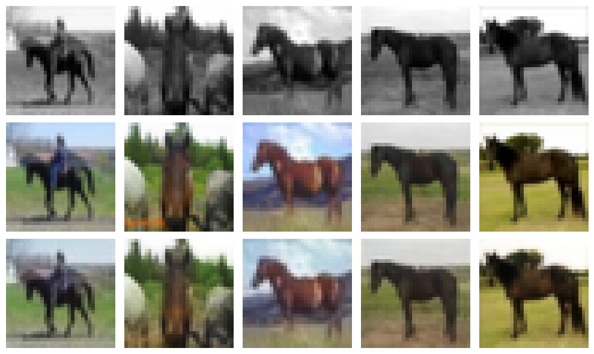

```
Saved final checkpoints:
  G -> outputs/resunet_cgan/ResUNetGenerator.pt
  D -> outputs/resunet_cgan/Discriminator.pt
```

```python
args = AttrDict()
args_dict = {
    "gpu": True,
    "model": "ResUNetGenerator",
    "kernel": 3,
    "num_filters": 64,        # D width (G uses ResNet widths internally)
    "learn_rate": 2e-4,
    "batch_size": 32,
    "epochs": 50,
    "seed": 0,
    "plot": True,
    "experiment_name": "resunet_cgan",
    "visualize": False,
    "downsize_input": False,
    "freeze_encoder": True,
    "unfreeze_at": 5,
    "l1_lambda": 100.0,
}
args.update(args_dict)
cnn = train(args)
```

```python
# ------------------------- Model on Test Model -------------------------
def eval_on_test(args, batch_size=64):
    # 1) build model by name in args["model"]
    M = globals()[args["model"]]
    try:
        G = M(args.get("kernel",3), args.get("num_filters",64), num_colours=3,
              num_in_channels=(1 if not args.get("downsize_input",False) else 3))
    except TypeError:
        try: G = M(args.get("kernel",3), args.get("num_filters",64))
        except TypeError: G = M()  # e.g., ResUNetGenerator()

    # 2) load the checkpoint saved by train(): outputs/<experiment_name>/<model>.pt
    ckpt = os.path.join("outputs", args.get("experiment_name","exp"), f'{args["model"]}.pt')
    if not os.path.exists(ckpt):
        raise FileNotFoundError(f"Checkpoint not found: {ckpt}")
    G.load_state_dict(torch.load(ckpt, map_location="cpu"))
    print(f"Loaded weights: {ckpt}")

    # 3) device & eval
    dev = "cuda" if (args.get("gpu",False) and torch.cuda.is_available()) else "cpu"
    G = G.to(dev).eval()

    # 4) data
    (_, _), (x_test, y_test) = load_cifar10()
    test_rgb, test_grey = process(x_test, y_test, downsize_input=args.get("downsize_input",False))

    # 5) metrics + show only last batch
    L1, MSE = nn.L1Loss(reduction="sum"), nn.MSELoss(reduction="sum")
    s1 = s2 = n = 0.0
    last_images = last_labels = last_outputs = None
    for xs, ys in get_batch(test_grey, test_rgb, batch_size):
        images, labels = get_torch_vars(xs, ys, gpu=(dev=="cuda"))
        preds = G(images)
        b = labels.size(0)
        s1 += L1(preds, labels).item()
        s2 += MSE(preds, labels).item()
        n  += b * labels.size(1) * labels.size(2) * labels.size(3)
        last_images, last_labels, last_outputs = images, labels, preds

    l1 = s1 / n
    mse = s2 / n
    psnr = 10.0 * math.log10(1.0 / max(mse, 1e-12))
    print(f"[TEST] L1={l1:.6f}  MSE={mse:.6f}  PSNR={psnr:.2f} dB")

    visual(last_images, last_labels, last_outputs, gpu=(dev=="cuda"), flag_torch=1, losses=None)
```

```
Loaded weights: outputs/resunet_cgan/ResUNetGenerator.pt
File path: data/cifar-10-batches-py.tar.gz
[TEST] L1=0.041889  MSE=0.003426  PSNR=24.65 dB
```

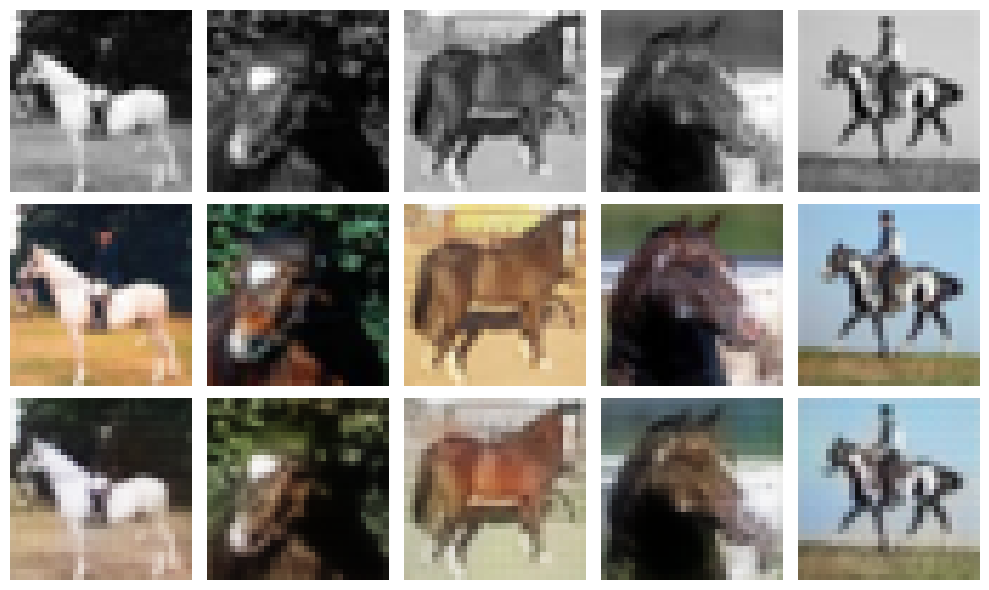

```python
eval_on_test(args_dict)
```

```python
'''
My observation on incoporating ResNet:

Using a ResNet18-initialized U-Net generator with a conditional discriminator and BCE+L1 loss, my model produced noticeably sharper and more semantically plausible colorizations than the earlier
transpose-conv autoencoder.

Edges (mane/legs, horizon) were better preserved and color bleed reduced, consistent with skip connections reusing high-frequency details and the pretrained encoder supplying
object-level cues (horse/sky/grass).

A medium batch size (≈32) offered the best stability–detail trade-off; very large batches tended to desaturate, while very small batches introduced artifacts.

A key lesson was to match preprocessing with the output activation. I think to improve this, I can add perceptual/patch losses and scale to higher native resolutions.


'''
```

[output not shown]

[output not shown]

### Saving to HTML

Detailed instructions for saving to HTML can be found [here](https://stackoverflow.com/questions/53460051/convert-ipynb-notebook-to-html-in-google-colab/64487858#64487858). Provided below are a summary of the instructions:

(1) download your ipynb file by clicking on File->Download.ipynb

(2) reupload your file to the temporary Google Colab storage (you can access the temporary storage from the tab to the left)

(3) run the following:

```python
%%shell
jupyter nbconvert --to html /content/A3.ipynb
```

(4) the html file will be available for download in the temporary Google Colab storage

(5) review the html file and make sure all the results are visible before submitting your assignment to Quercus

# Assignment Grading Rubric

The grading of the assignment will be based on the following categories:

(1) **10 Pt - EXPLORATORY QUESTIONS** These are basic questions that in most cases can be answered without requiring a fully working and trained neural network model. For example, data loading, processing and visualization, summary statistics, data exploration, model and training setup, etc.

(2) **10 Pt - MODEL** Student has successfully implemented all the required neural network models and has demonstrated successful training of the model without any errors.

(3) **10 Pt - RESULT** Students are evaluated based on the results achieved in comparison to the expected results of the assignment.

(4) **10 Pt - DISCUSSION QUESTIONS** Student demonstrated understanding beyond the basic exploratory questions, can answer some of the more challenging questions, and provide arguments for their model selection decisions.

(5) **10 Pt - COMMUNICATION** Student has provided a quality submission that is easy to read without too many unnecessary output statements that distract the reading of the document. The code has been well commented and all the answers are communicated clearly and concisely.

(6) **5 Pt - BONUS** Student has completed the assignment and has taken on the challenging bonus tasks listed in PART C. The student has demonstrated a good understanding of all aspects of the assignment and has exceeded expectations for the assignment.

**TOTAL GRADE = _____ of 50 Pts**